# Introduction to transport data science

Module: Transport Data Science

Robin Lovelace

2026-10-22

## Who: Transport Data Science team

#### Robin Lovelace

- Professor of Transport Data Science
- Researching transport futures and active travel planning
- Data scientist, web application developer, author of Geocomputation with R

#### Yuanxuan Yang

- Lecturer in Data Science of Transport
- New and Emerging Forms of Data: Investigating novel data sources and their applications in urban mobility and transport planning.

## TDS Team II

#### Malcolm Morgan

- Senior researcher at ITS with expertise in routing + web
- Developer of the Propensity to Cycle Tool and [PBCC](https://www.carbon.place/#8/51.482/-0.151)

#### Demonstrators

- Juan Pablo Fonseca Zamora

#### You!

## What is transport data science?

- The application of data science to transport datasets and problems
- Raising the question…
- What is data science?
- A discipline “that allows you to turn raw data into understanding, insight, and knowledge” (Grolemund, 2016)

In other words…

- Statistics that is actually useful!

## Why take Transport Data Science

- New skills using emerging technologies including AI
- Potential for impacts
- Allows you to do new things with data
- It might get you a job!

[figure not shown]

[figure not shown]

[figure not shown]

## Live demo: [npt.scot web app](https://nptscot.github.io/)

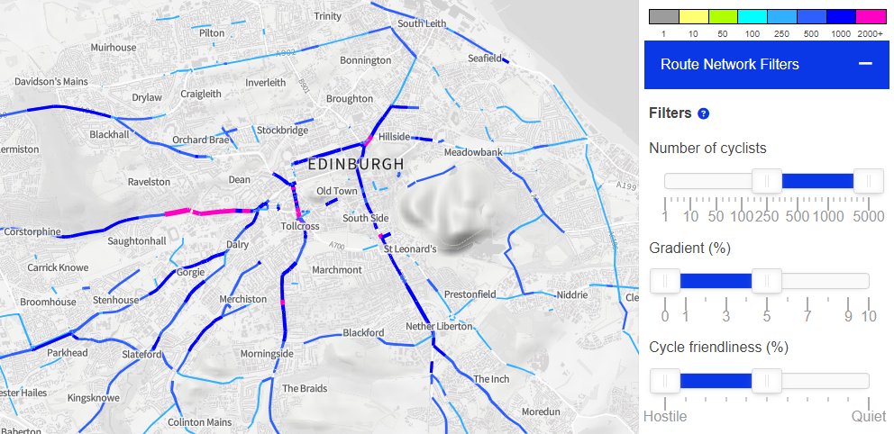

## Module development

- 2020: Available to Data Science students
- 2021-2024: Updated module, focus on methods
- 2025: Python + Quarto support
- 2026: AI-powered coding
- 2027+: Available to all MSc students in ITS 🚀

[figure not shown]

## Essential reading

- Chapter 13, [Transportation](http://r.geocompx.org/transport.html) of Geocomputation with R, a open book on geographic data in R (available free [online](http://r.geocompx.org/)) (Lovelace et al. 2019)
- Reproducible Road Safety Research with R (RRSRR): https://itsleeds.github.io/rrsrr/

## Core reading materials

- R for Data Science, an introduction to data science with R (available free [online](http://r4ds.had.co.nz/))
- Python for Data Analysis (available [online](https://wesmckinney.com/book/) for free)

#### Objectives

1. Understand the structure of transport datasets, from origin-destination to street segment levels.
2. Understand how to obtain, clean, and store transport-related datasets.
3. Proficiency in command-line tools for handling large transport datasets.
4. Produce data visualizations, both static and interactive via web maps.
5. Learn where to find large transport datasets and assess data quality.
6. Learn how to join together the components of transport data science into a cohesive project portfolio.

## [Schedule](https://itsleeds.github.io/tds/schedule.html)

| Session ID | Slides | Practical | Description | Time | Duration | Location |
| --- | --- | --- | --- | --- | --- | --- |
| s1 | Slides |  | TDS Session 1 Lecture: Introduction to transport data science (RL, MM, YY) Located in Michael Sadler SR (LG.15) | 2027-01-28 10:00 | 1 | Michael Sadler SR (LG.15) |
| s1 |  | Practical | TDS Session 1 Practical: Introduction to transport data science (RL, MM, YY) Located in Michael Sadler SR (LG.15) | 2027-01-28 11:00 | 2 | Michael Sadler SR (LG.15) |
| d1 |  | Assessment | Computer set-up | 2027-01-29 13:00 | 2 | Online - Teams |
| s2 | Slides |  | TDS Session 2 Lecture: Getting transport data (RL, YY) Located in Michael Sadler SR (LG.15) | 2027-02-04 10:00 | 1 | Michael Sadler SR (LG.15) |
| s2 |  | Practical | TDS Session 2 Practical: Getting transport data (RL, YY) Located in Michael Sadler SR (LG.15) | 2027-02-04 11:00 | 2 | Michael Sadler SR (LG.15) |
| s3 | Slides |  | TDS Session 3 Lecture: AI for transport planning (RL, YY) Located in Michael Sadler SR (LG.15) | 2027-02-11 10:00 | 1 | Michael Sadler SR (LG.15) |
| s3 |  | Practical | TDS Session 3 Practical: AI for transport planning (RL, YY) Located in Michael Sadler SR (LG.15) | 2027-02-11 11:00 | 2 | Michael Sadler SR (LG.15) |
| s4 |  |  | TDS Session 4 Lecture: Origin-destination data (RL, YY) Located in Institute for Transport Studies Room 1.11a-c | 2027-02-18 10:00 | 1 | Institute for Transport Studies Room 1.11a-c |
| s4 |  | Practical | TDS Session 4 Practical: Origin-destination data (RL, YY) Located in Institute for Transport Studies Room 1.11a-c | 2027-02-18 11:00 | 2 | Institute for Transport Studies Room 1.11a-c |
| sem1 |  | Practical | Seminar 1: Juan Fonseca, University of Leeds: Processing and visualising traffic datasets | 2027-02-18 14:00 | 3 | Institute for Transport Studies Room 1.11a-c |

[output cut: 7 more lines]

## Feedback

### 2024

> The module is taught by two really well organised and enthusiastic professors, great module, the seminars, structured and unstructured learning was great and well thought out, all came together well

> I wish this module was 60 credits instead of 15 because i just want more of it.

### 2025

> The leaders were incredibly helpful during practical sessions and feedback was constructive. I liked having the opportunity to discuss what I had achieved so far with peers, as this led to the sharing of ideas and insight from other degree disciplines also.